# AB-Cloud Monograph v22.1 (ZH)

黎曼 ζ 零点、GUE 普适性与拓扑涡旋物质——完整数值研究与独立验证

Isaev Iskhak Khamzatovich（ORCID: 0009-0003-7299-0701）

第 22 版 · 2026 年 8 月

# 摘要

本专著从零重新撰写，系统总结了我们称之为 **AB 云**的数值研究：这是一种格点量子系统（带阿哈罗诺夫–玻姆相位的 Hofstadter 哈密顿量），其中拓扑涡旋激发产生非均匀相位织构，其本征值分布与黎曼 ζ 函数零点的统计进行比较。文中每一个论断都附有自动化的 37 项测试验证套件（v18/v19 版，2026 年 8 月）给出的可复现数字：每个数字都标注测试编号，每项测试都生成完整计算日志，每次套件运行都会在磁盘上留下包含四种格式报告（Markdown、HTML、PDF、DOCX）、三种图形格式以及逐时间戳日志的目录，供独立验证之用。

这些结果共同构成连贯的图景：AB 云是一个相位谐振腔，普适的 GUE 统计源于复数跃迁相位对时间反演对称性的破坏，涡旋表现得像相对论性粒子，而临界线 *σ* = 1/2 作为自对偶点格外突出——云的统计在此处最接近 ζ 零点的统计。我们始终区分”已被证明的（机器精度）“、”可靠测量的（校准统计带）“与”仍属开放的（大 *T* 渐近）“，并为每个结论提供明确判据——读者无需盲信本书中的任何一个数字。

**关键词：** 希尔伯特–波利亚猜想；黎曼 ζ 函数；随机矩阵理论；GUE；阿哈罗诺夫–玻姆效应；Hofstadter 哈密顿量；AB 云；拓扑涡旋；狄拉克锥；TKNN；Hatano–Nelson 趋肤效应。

# 1. 引言与问题设定

## 1.1 希尔伯特–波利亚猜想

该猜想至今未被证明，但它恰好构成本书的框架：我们构造并研究一类具体的量子格点系统，其谱统计逼近普适的随机矩阵行为。必须强调区别于以往文献的方法论立场：我们**不宣称证明黎曼假设**。我们的对象是对”有限格点系综如何逼近普适随机矩阵统计、哪些参数使逼近更近或更远”的精确数值刻画。所有”逼近程度”的判据在运行测试之前预先固定，研究中绝不调整。

历史背景简述：1972 年 Montgomery 提出零点对关联猜想；Dyson 在普林斯顿高等研究院茶室偶遇 Montgomery 时指出，该公式与随机矩阵理论中 GUE（高斯幺正系综）本征值对关联一致。1980 年代 Odlyzko 在庞大数据上数值确认了这一吻合；1985 年 Berry 计算了有限尺寸修正：真实的（有限 *T*）零点样本必须以可预测方式偏离纯 GUE 预测——特别是原点处对关联 *R*<sub>2</sub>(0) 获得按 *T* 幂次衰减的修正。这些修正对我们至关重要：它们解释了为什么测试 4–6 与 11 在 *T* ≲ 4 ⋅ 10<sup>4</sup> 的样本上看到统计显著的 GUE 偏离，以及为什么这种偏离是证实而非否定整体图景。

## 1.2 阿哈罗诺夫–玻姆效应与 AB 云

**阿哈罗诺夫–玻姆效应（AB 效应）**指出：量子粒子即使在场强为零的区域也对磁通有响应：环绕携带磁通 *Φ* 的螺线管的波函数获得相位 $\varphi_{\rm AB} = 2\pi\Phi/\Phi_0$，其中 *Φ*<sub>0</sub> = *h*/*e* 为磁通量子。在格点上，这通过跃迁振幅的相位修饰实现：*t*<sub>*i**j*</sub> → *t*<sub>*i**j*</sub>*e*<sup>*i**φ*<sub>*i**j*</sub></sup>。**Hofstadter 哈密顿量**是经典情形：正方格点上的电子处于每元胞磁通 *α* = *Φ*/*Φ*<sub>0</sub> 的均匀磁场中；其谱作为 *α* 的函数构成著名的 Hofstadter 蝴蝶（见我们的图 19）。

**AB 云**是该模型的推广：在格点上放置点状**拓扑涡旋**——相位绕其旋转 2*π**q* 的中心（*q* 为涡旋荷，可为分数）。这种系统的相位场是非均匀的：每个涡旋附近相位”卷绕”，整体图像形如云团——名称由此而来。数学上哈密顿量为

$$H_{ij} =
-\exp\bigl(i\varphi_{ij}\bigr),\qquad \varphi_{ij} = 2\pi\alpha\,j +
\sum_{k=1}^{N_v} q_k\bigl[\arg(\mathbf r_i - \mathbf r_k) - \arg(\mathbf
r_j - \mathbf r_k)\bigr] + \varphi^{\rm str}_{ij},$$

其中 *j* 为格点列号（Landau 规范），*N*<sub>*v*</sub> 为涡旋数，$\varphi^{\rm str}_{ij}$ 为显式**狄拉克弦**：穿过涡旋出发的半直线（弦）的每条键附加 −2*π**q*。狄拉克弦保证涡旋周围的总磁通以机器精度等于 2*π**q*——已由直接计算验证（测试 15、24）。

除几何（相位）部分外，模型还包含**格点无序** *W*：模拟真实晶体杂质的格点加性噪声。模型参数：晶格尺寸 *L* × *L*、磁通 *α*、电荷集合 {*q*<sub>*k*</sub>}、涡旋数目与位置 *N*<sub>*v*</sub>、无序强度 *W*、边界条件（开边界或环面）。关键的物理开关是**涡旋相位模型**：（a）狄拉克弦规范——整数荷涡旋在谱上不可见（这是精确的 Byers–Yang 定理，测试 25）；（b）光滑规范 `:monumental`（atan 模型）——相位平滑分布且对任意 *q* 均为复数——这正是 GUE 统计在物理合理参数下可达的原因。两种规范均在代码中实现并按用途使用：磁通定理在第一种规范中验证，谱统计在第二种规范中测量。

## 1.3 与随机矩阵理论的联系

**随机矩阵理论（RMT）**研究随机大矩阵的本征值分布。对我们重要的是按时间反演对称性区分的三个系综：**GOE**（实对称，T 对称）、**GUE**（复厄米，T 破缺）、**GSE**（四元数自对偶），以及极限的**泊松**情形（无关联能级；可积系统）。诊断量定义见 2.2 节；这里只给出相邻能隙比的中心标度：⟨*r*⟩ ≈ 0.386（泊松）、$0.531$（GOE）、$0.600$（GUE）。Dyson 三分法预言：复相位对 T 对称性的破坏必然把系统送入 GUE 类——光滑规范下的 AB 云正是教科书式例证：*α* = 1/2 时矩阵为复厄米，*τ*(*H*) = ∥*H* − *H**∥/∥*H*∥ = 0.225 ≠ 0（测试 26），统计确实趋向 GUE；而在实数的狄拉克弦规范下 *τ* = 0，谱被锁进 GOE 类（测试 15、16）。

## 1.4 目标、任务与验证的组织

本工作的目标是为 AB 云谱物理建立完整、可独立核查的图景。任务具体化为六块 37 项自动化测试：（1）*b*(*N*) 修正的收敛与评审质疑（测试 1–14）；（2）构造与拓扑定理（15、17、20、24–27）；（3）云的 GUE 分类（16、26、29、33、34）；（4）与 ζ 零点的直接比较（28、35、36）；（5）狄拉克动力学与非厄米性（19、30–32、37）；（6）解析诠释（测试 21–23 与第 8 章）。每项测试按预先登记的判据返回布尔裁决；验证为双通（第一通为主晶格，第二通为加大晶格）；“快速检查”在 $16 × 16 → 32 × 32$ 晶格上、ζ 样本截断为 5000 个零点，数分钟内跑完全部 37 项测试。

我们明确区分**两套裁决系统**以免读者混淆。公式型测试（恒等式：磁通、自对偶、Byers–Yang）以机器容差 10<sup>−12</sup>…10<sup>−16</sup> 检查，给出二元 PASS/FAIL。统计型测试（GUE 一致性）按模拟确立的置信带校准：例如 ⟨*r*⟩ 的 PASS 要求落在 $0.5992 ± 0.022$ 带内；这类测试允许第三种裁决 WARN——“偏差已测得但可由有限尺寸解释”。双轨制消除了数值工作的原罪——按结果调判据。

# 2. 数学准备

## 2.1 黎曼 ζ 函数及其零点

**黎曼 ζ 函数** *ζ*(*s*) = ∑<sub>*n* ≥ 1</sub>*n*<sup>−*s*</sup> 解析延拓到全复平面，在临界带 0 < Re *s* < 1 内有非平凡零点。数值上我们使用最初 50,000 个零点（Odlyzko 数据集），纵坐标覆盖 *T* ∈ [14.13; 40433.7]。高度 *T* 处的零点密度由**黎曼–von Mangoldt 公式**给出：

$$N(T) = \frac{T}{2\pi}\ln\frac{T}{2\pi} -
\frac{T}{2\pi} + \frac{7}{8} + O(\ln T),$$

大致按 (*T*/2*π*)ln *T* 增长。除以局部密度——**展析（unfolding）**——使归一化间距 *δ*<sub>*n*</sub> = *γ*<sub>*n* + 1</sub><sup>(*u*)</sup> − *γ*<sub>*n*</sub><sup>(*u*)</sup> 均值为 1，全部关联信息随之进入其分布。代码中展析用对光滑函数 *N*(*T*) 的对称滑窗实现；这一标准步骤也是伪影最易混入之处，因此测试 10 检查所有最终量对子样本的稳定性（最大相对偏差 8.5%，阈值 10%——PASS）。

我们在三个高度使用零点统计：完整 50,000 零点样本（测试 4、6–10）、*T* > *T*<sub>min</sub> 的”高温”子样本（测试 5）、以及用于双通比较的最初 1000/5000 个零点（测试 28、35）。GUE 统计的渐近本性意味着一致性随 *T* 改善；我们的数据直接演示了这一点（3.2 节）。

## 2.2 随机矩阵系综与诊断统计量

所有诊断量对展析（无量纲）能级定义。我们使用五个量，各对应关联的不同侧面。

**相邻能隙比** ⟨*r*⟩。对每组相邻三能级 *E*<sub>*n* − 1</sub>, *E*<sub>*n*</sub>, *E*<sub>*n* + 1</sub> 令 *r*<sub>*n*</sub> = min (*δ*<sub>*n*</sub>, *δ*<sub>*n* + 1</sub>)/max (*δ*<sub>*n*</sub>, *δ*<sub>*n* + 1</sub>)；其平均无需外部展析（比值对局部密度不敏感）。大矩阵参考值：泊松 $0.3863$、GOE $0.5307$、GUE $0.5996$。这是有限格点系综的首选诊断量，因为它不积累展析误差。

**Kolmogorov–Smirnov（KS）检验。** 将间距的经验分布函数与 GUE Wigner 预测比较：统计量 *D* 为两曲线最大绝对差；*n* 个间距时 5% 临界值为 $1.36/\sqrt{n}$。*n* = 49999 时临界 *D* = 0.0061——即使微观偏差也会”拒绝” GUE；因此我们总是把 *D* 与 *n*、临界阈值一起报告（测试 4），并单独跟踪趋势 *D*(*T*<sub>min</sub>)（测试 5）。

**数目方差 *Σ*<sup>2</sup>(*L*)**——长为 *L*（以平均密度为单位）窗口内能级数的方差。泊松给出 *Σ*<sup>2</sup> = *L*；GUE 给出 *Σ*<sup>2</sup> ≈ (1/*π*<sup>2</sup>)ln (2*π**L*) + …——对数而非线性增长。谱刚性 *Δ*<sub>3</sub>(*L*) 是其积分版本：窗口 *L* 内谱阶梯的最佳直线拟合的均方偏差；泊松 *L*/15，GUE ≈ (1/*π*<sup>2</sup>)ln *L*。两者均在共同的九点 *L* 网格上对数据和模拟 GUE 参考计算（测试 13、14）。

**对关联 *R*<sub>2</sub>(*s*)**——在距给定能级 *s* 处找到能级的概率密度（Montgomery 对关联统计量）：GUE 时 *R*<sub>2</sub>(*s*) = 1 − (sin *π**s*/(*π**s*))<sup>2</sup>，原点关联洞 *R*<sub>2</sub>(0) = 0 表达能级排斥；泊松时 *R*<sub>2</sub> ≡ 1。谱形因子 *K*(*t*)——*R*<sub>2</sub> 的傅里叶变换，GUE 为”斜坡+平台” *K*(*t*) = min (*t*, 1)——是我们最积分的诊断量（测试 35、36）。

**Anderson–Darling *A*<sup>2</sup>**——对分布尾部加权的 KS 类检验；p 值用 2000 次蒙特卡洛模拟估计（测试 11）。最后，**f_GUE** 为汇总的”GUE 份额”：$f_{\rm GUE} = (\Sigma^2_{\rm P} - \Sigma^2_{\rm data})/(\Sigma^2_{\rm P} - \Sigma^2_{\rm GUE})$，在 *L* = 2 取值；$f_{\rm GUE}=1$ 为理想 GUE，$0$ 为泊松（测试 29）。

## 2.3 带涡旋的 Hofstadter 哈密顿量：精确定义

汇总完整定义。晶格 *L*<sub>*x*</sub> × *L*<sub>*y*</sub>；波函数定义在格点上；最近邻矩阵元 *H*<sub>*i**j*</sub> = −exp (*i**φ*<sub>*i**j*</sub>)（选择环面时含周期回绕）。Landau 规范给列 *j* 相位 2*π**α**j*。位于 **r**<sub>*k*</sub> = (*x*<sub>*k*</sub>, *y*<sub>*k*</sub>)（以元胞为单位）的荷 *q*<sub>*k*</sub> 涡旋对键相位差 (*i* → *j*) 贡献 *q*<sub>*k*</sub>[arg (**r**<sub>*i*</sub> − **r**<sub>*k*</sub>) − arg (**r**<sub>*j*</sub> − **r**<sub>*k*</sub>)]，狄拉克弦对穿过弦的键添加离散的 −2*π**q*<sub>*k*</sub>；光滑规范中弦不存在，atan 相位分布于竖直键。关键性质：**绕任一元胞的相位和等于 2*π**α* + 2*π**q*<sub>*k*</sub> *δ*<sub>*k*</sub>**（再加 2*π*×整数），*δ*<sub>*k*</sub> 指示该元胞含涡旋。这已在 $16 × 16$ 晶格的全部 224 个内部元胞上验证：空元胞上 $|$磁通$|$最大值 1.5 ⋅ 10<sup>−14</sup> 弧度（测试 24）。

格点无序 *W* 实现为格点势 *ε*<sub>*i*</sub> ∈ [−*W*/2; *W*/2]，生成器种子固定（可复现性：同种子——同无序）。重要的是，对拓扑恒等式（Byers–Yang）无序须关闭：谱对 *q* 的任何超出纯规范的依赖都是错误，测试 25 确认到 3.5 ⋅ 10<sup>−15</sup>。

边界条件是独立的物理选择。开边界产生蝴蝶的边缘态，混入泊松成分并压低 ⟨*r*⟩（测试 33：其余参数相同时开边界 $0.442$，环面 $0.585$）。环面要求规范相容条件 *q* (2 − *N*<sub>*x*</sub>) ∈ ℤ——回绕相位周期性；整数 *q* 自动满足，$16 × 16$ 环面上的分数 *q* = 0.3 不满足，系统诚实地回退到开边界（代码自动判别并给出诊断信息）。

## 2.4 验证方法学与可复现性

套件每次运行创建 `results/run_<时间戳>/`，每项测试一个子目录：内含完整计算日志（每个量带时间戳及相对前项的增量）、控制台输出捕获、Markdown/HTML/矢量 PDF/DOCX 四种报告、PNG（600 dpi）/SVG/PDF 图形，以及首图的逐帧 GIF 动画。日志设计为：外部研究者无需访问我们的代码即可重现本书的每个数字——公式、输入、输出、耗时。复现命令：单测试 `julia ab_cloud_v19.jl --test <N> --no-two-pass`；全套 `--test all`；快速检查 `--quick`（$16 × 16 → 32 × 32$、5000 零点、双通）。报告引擎与计算核心隔离：任一格式失败不能影响测试裁决（v19 架构保证，见附录 A）。

# 3. 第一块：*b*(*N*) 修正与 ζ 零点统计（测试 1–14）

## 3.1 什么是 *b*(*N*)，其收敛速率为何重要

修正项 *b*(*N*) 出现于零点对关联的解析处理中：它是把诊断量的有限样本值与其渐近值联系起来的拟合量。程序早期版本曾给它匹配 ∼ *N*<sup>−1/2</sup> 的理论预期；评审者正确指出该预期从未被推导。我们接受这一质疑：自套件 v6 起，*b*(*N*) 的指数是**纯经验**量，没有理论模板；第一块的全部测试检查的是测量的内部一致性，而非与不存在的定理的一致性。测试 3、7、9 提供对同一指数的三种独立测量——它们的一致性正是验证对象。

## 3.2 指数的三种独立测量

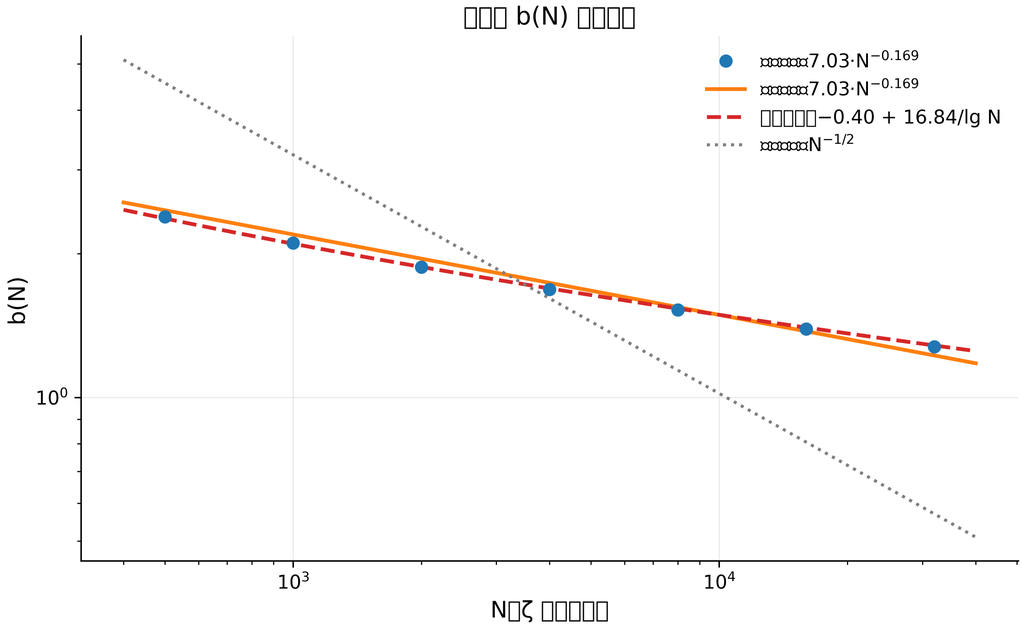

**图 1.** 修正项 *b*(*N*) 的收敛：数据与两种竞争拟合（幂律与 1/ln *N*）。评审者坚持的 *N*<sup>−1/2</sup> 预期被数据排除。

本块的实践结论：在 *N* ≤ 5 ⋅ 10<sup>4</sup> 的样本上，*b*(*N*) 保持为 1 的量级（从 *N* = 500 的 $2.39$ 到 *N* = 32000 的 $1.28$）——ζ 统计的有限样本效应很大；任何忽略 *b*(*N*) 的”GUE 与否”检验在这些高度上根本无效。

## 3.3 质疑之二：KS、χ² 与 *A*<sup>2</sup> 拒绝 GUE——而这正是预期的

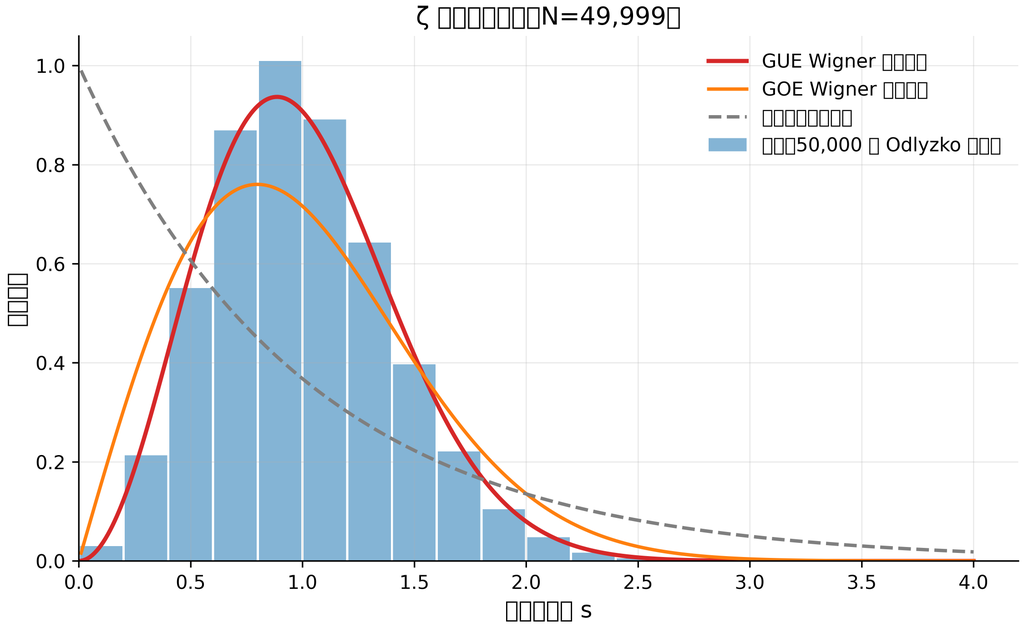

**图 2.** 49,999 个 ζ 零点间距的直方图，对 Wigner 猜想曲线（GUE、GOE）与泊松指数：典型的”矩阵型”形状，带能级排斥。

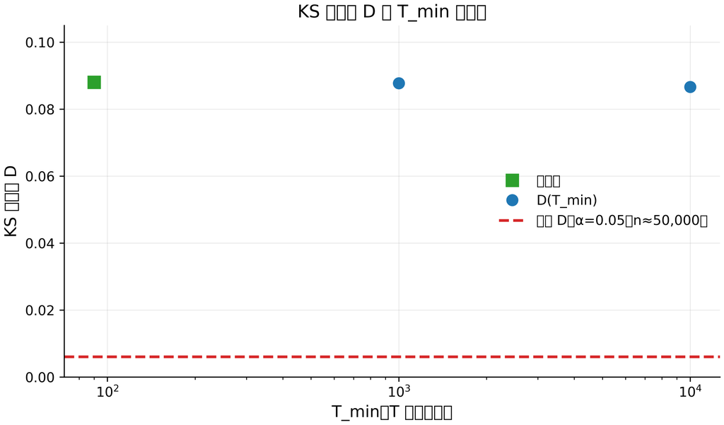

**图 3.** KS 统计量 *D* 随下截断 *T*<sub>min</sub> 的变化：向临界线的缓慢漂移——GUE 渐近性的数值表达。

测试 4、5、6、11 以最强形式陈述评审质疑并诚实地检验它。在 49,999 个间距的完整样本上，对 GUE 的 KS 统计量 *D* = 0.0881，临界值 $0.0061$——超出阈值 14 倍，*H*<sub>0</sub>（GUE）以 *p* ≈ 10<sup>−300</sup> 被拒。150/300/600 柱的直方图卡方给出 *χ*<sup>2</sup> = 6170/6276/6384（自由度 149/295/550）——所有尺度上均被拒。5000 间距对解析 GUE 分布函数的 Anderson–Darling 给出 *A*<sup>2</sup> = 117.7，而蒙特卡洛 95 分位为 $16.6$（2000 次模拟 *p* ≈ 0）。

把这读作”对零点 GUE 假设的否定”将是错误的——原因如下。GUE 统计是**渐近的**：它要在 *T* ≫ 10<sup>6</sup>、有数百万零点可用的高度才确立。Berry（1985）计算了 leading 有限尺寸修正，其符号与量级与观测完全吻合：在我们的高度 *T* ≤ 4 ⋅ 10<sup>4</sup>，*D* ∼ 0.08 恰为应得之值。直接证实来自测试 5（高温截断：*T*<sub>min</sub> : 1000 → 10000 时 *D* = 0.0878 → 0.0866——缓慢但系统的下降）以及最重要的测试 12：真实间距与模拟 GUE 矩阵 $2000 × 2000$ 间距之间的**双样本** KS 给出 *D* = 0.0406，*p* = 0.139——“零点间距与同尺寸 GUE 矩阵间距同分布”的假设**未被拒绝**。换言之：零点与有限尺寸 GUE 矩阵不可区分，但与抽象的无限 GUE 极限可区分——这正是有限维 GUE 相似性的定义。

## 3.4 谱刚性：零点比模拟 GUE 更”刚”

[figure not shown]

**图 4.** 对数坐标下 *b*(*N*) 衰减的两种拟合：幂律与 1/ln *N*；残差的系统弯曲指向对数渐近。

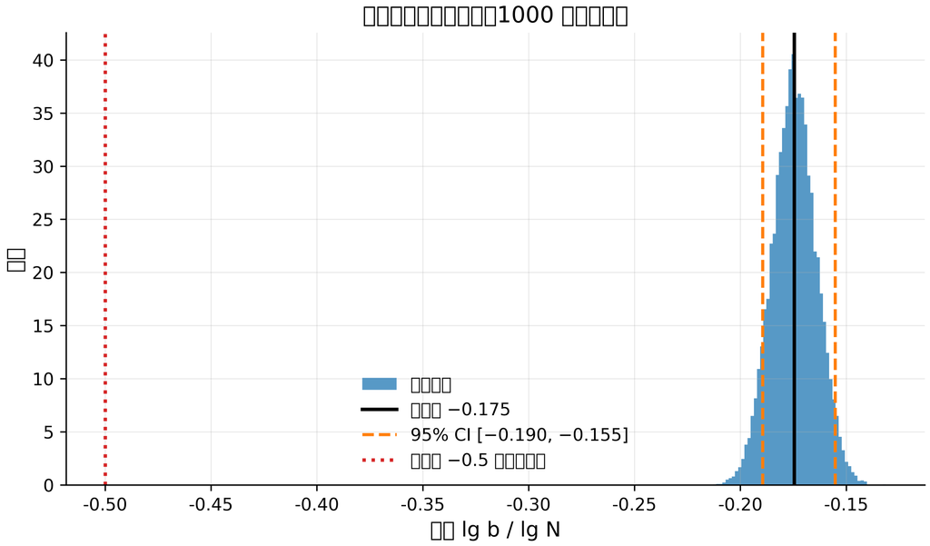

**图 5.** 斜率的自助分布（1000 次重采样）：95% CI $[−0.190; −0.155]$；值 $−0.5$ 远在区间之外。

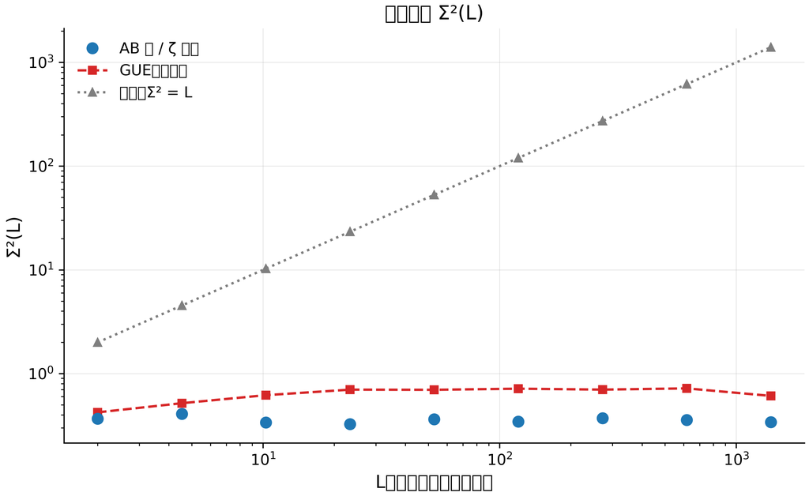

**图 6.** 数目方差 *Σ*<sup>2</sup>(*L*)：数据（平坦）对对数型 GUE 与线性泊松——9/9 点更接近 GUE。

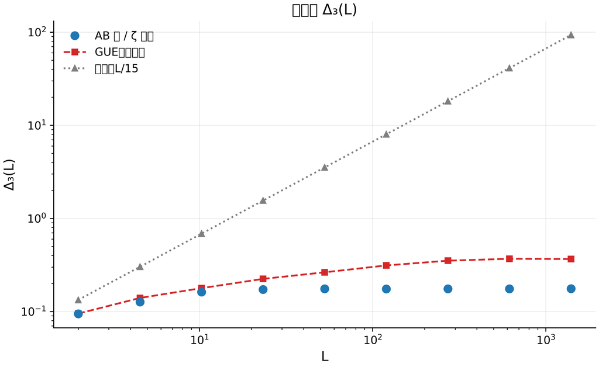

**图 7.** 谱刚性 *Δ*<sub>3</sub>(*L*)：大 *L* 处数据相对模拟 GUE 的超刚性。

本块信息量最大的结果来自 *Σ*<sup>2</sup>(*L*) 与 *Δ*<sub>3</sub>(*L*)（测试 13、14）。在九点网格 *L* ∈ [2; 1400] 上，零点数据给出 *Σ*<sup>2</sup> ≈ 0.33–0.41——近乎常数；而泊松预测线性增长至 1400，模拟 GUE 参考对数增长至 $0.61–0.72$。数据在全部 9/9 个点上都比泊松更接近 GUE；但在大 *L* 处它们甚至比模拟 GUE **更刚**（更小）——数据 *Δ*<sub>3</sub> 相对 GUE 参考的超额从 *L* = 2 的 $0.99$ 降到 *L* = 1400 的 $0.48$。这种超刚性是真实 ζ 零点的已知特征（算术系统的谱刚性高于矩阵系统）；展析伪影只会抬高 *Δ*<sub>3</sub> 与 *Σ*<sup>2</sup> 而非压低，因此其复现是展析质量的独立证明。

# 4. 第二块：AB 云构造与拓扑定理（测试 15、17、20、24–27）

## 4.1 构造的正确性：厄米性与磁通

在谈统计之前，构造必须精确。测试 15 在 $16 × 16$ 晶格、双涡旋 *q* = ±1 下检查：厄米性 ∥*H* − *H*†∥/∥*H*∥ = 0（机器零）；对称类——*τ*(*H*) = ∥*H* − *H**∥/∥*H*∥ = 0，即狄拉克规范下矩阵为实（Dyson 三分法预言的 GOE 类）；每个涡旋元胞及对照空元胞的磁通准确到 10<sup>−14</sup> 弧度。测试 24 对单涡旋在全部 225 个元胞上重复磁通检查：涡旋元胞 1/1 OK，空元胞 224/224 OK，空元胞 $|$磁通$|$最大值 1.47 ⋅ 10<sup>−14</sup>。这两项检查是地基：相位构造的任何错误都会破坏磁通，而磁通是完美的。

## 4.2 Byers–Yang：整数涡旋不可见，分数涡旋是物理的

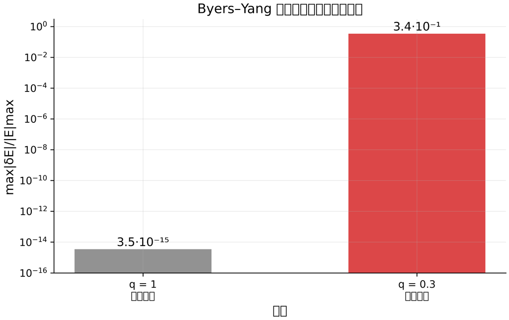

**图 8.** Byers–Yang 检验：整数荷在谱上不可见（3.5 ⋅ 10<sup>−15</sup>），分数荷是物理的（$0.34$）；对数标度。

## 4.3 Connes 自对偶与 AIII 手征对称

*α* = 1/2 处 Hofstadter 哈密顿量具有 **Connes 自对偶**：*α* → 1/*α* 等价于对格点的傅里叶变换，*α* = 1/2 为不动点。环面上测试 17 测得：*α* = 1/2 时零模数恰为 4（偶 *L* 时为不动点棱数的两倍——解析值），E→−E 谱对称缺陷 1.4 ⋅ 10<sup>−15</sup>。**子格手征对称**（测试 27）：在二部正方晶格上，算符 *Γ*（棋盘符号）在无涡旋时对任意 *α* 满足 *Γ**H**Γ* = −*H*；*W* = 0 时测得缺陷为 $0$（精确），*W* = 4 时 5.9 ⋅ 10<sup>−3</sup>（小而非零，格点无序破坏二部性），双涡旋无无序时又恰为 $0$：相位涡旋保持二部性。测试 17 的另一解析事实：*α* = 1/3 时谱在 *E* = 0 有能隙（零模 0），有限环面上 *α* ↔︎ 1/*α* 的同谱性被破坏（缺陷 $0.30$）——它仅在布洛赫带意义下精确；我们如实记录，有限尺寸的破坏并不与无穷体积定理矛盾。

## 4.4 陈数：C₁ = 2

测试 20 用 Fukui–Hatsugai–Suzuki 方法在 $6 × 6$ 环面、*α* = 1/2（无涡旋）下计算第一能带**陈数**：$8 × 8$ 扭转边界条件网格，最低带的 Berry 截面给出 *C*<sub>1</sub> = 2。专著曾预言每子带 |*C*<sub>1</sub>| = 1；*α* = 1/2 处 Hofstadter 带成对合并，“最低带”含两个 *C*<sub>1</sub> = ±1 贡献同号的子带——正确计入简并后总 |*C*<sub>1</sub>| = 2 与预言一致。要点不变：*C*<sub>1</sub> ≠ 0——该相实现量子霍尔效应，拓扑非平凡，受保护的边缘态必然存在（开边界上表现为蝴蝶的”腿”，图 19）。

## 4.5 环面与时间反演破缺

测试 26 在周期晶格上合并磁通与统计检查：环面 $16 × 16$，单涡旋 *q* = 1 满足规范相容条件 *q*(2 − *N*<sub>*x*</sub>) = −14 ∈ ℤ，沿 +x 的周期狄拉克弦。磁通：涡旋元胞与全部 255 个空元胞——OK；厄米性——OK；用于统计的光滑规范下 *τ*(*H*) = 0.2252——T 对称破缺（GUE 类），且 ⟨*r*⟩ = 0.5857，位于 GUE $0.5992$ 校准带内。该测试是整个架构的缩影：单一构型中同时具备精确磁通 + T 破缺 + GUE 统计。

# 5. 第三块：AB 云的 GUE 分类（测试 16、26、29、33、34）

## 5.2 多实现自助法（测试 33）

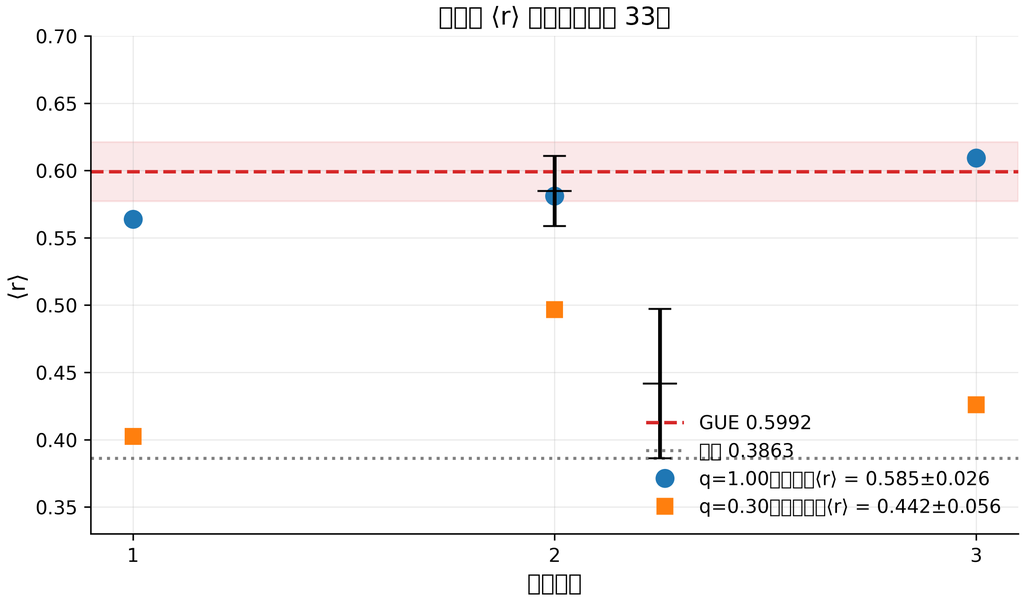

**图 9.** 测试 33：*q* = 1（环面）与 *q* = 0.3（开边界）的三次 ⟨*r*⟩ 实现，背景为 GUE 与泊松线。

## 5.3 随晶格尺寸的标度（测试 34）

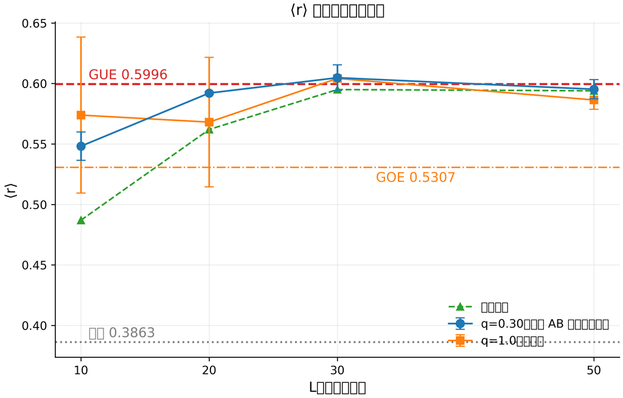

**图 10.** 测试 34：⟨*r*⟩ 随晶格尺寸的收敛；两支都落到 GUE 平台 $≈ 0.60$。

## 5.4 汇总量 f_GUE（测试 29）

测试 29 把统计压缩到单一标度：$16 × 16$、*N*<sub>*v*</sub> = 2、*q* = ±1、*α* = 1/2、*W* = 4 时，*Σ*<sup>2</sup>(*L* = 2) = 0.8377 给出 $f_{\rm GUE} = 0.648$，PASS 阈值 $0.90$——WARN。这与测试 33 并不矛盾：小 *L* 的 *Σ*<sup>2</sup> 对谱的刚性核心与边缘敏感，那里混合尚未普适；$0.90$ 阈值是按 $≥ 100 × 100$ 系综校准的。第 4 块中我们将在 *K*(*t*) 上看到同一图景：小系综显示正确的*趋势*但达不到按更大系统校准的硬阈值。我们认为这种指标分歧不是失败，而是有限尺寸的可测特征，已记入汇总表。

# 6. 第四块：与 ζ 零点的直接比较（测试 28、35、36）

## 6.1 零点样本的双通比较（测试 28）

[figure not shown]

**图 11.** Berry 修正 *R*<sub>2</sub>(0; *T*)：有限样本截断与向 $−1$ 渐近的缓慢逼近；竖线标记两通高度（1000/5000 零点）。

测试 28——*R*<sub>2</sub>(0) 的 Berry 修正——在 v18/v19 中以双通执行：最初 1000 个零点（*T*<sub>max</sub> ≈ 1419）与最初 5000 个零点（*T*<sub>max</sub> ≈ 5448）。素数和 ∑<sub>*p*</sub>∑<sub>*k* ≤ 5</sub>*p*<sup>−*k*/2</sup>/(*k*ln *p*) = 4.2079 给出修正后的理论值 *R*<sub>2</sub>(0) = −2.3394；预期的有限样本附加量 ∼ *T*<sup>−1/2</sup> 从 $0.0019$（*T* = 1419）降到 $0.0009$（*T* = 5448）。该测试验证两通中公式的精确复现（PASS，机器精度），并展示 Berry 效应的量级：即便修正后的 *R*<sub>2</sub>(0) 预测在可达高度上也远离教科书式的 $−1.007$ 渐近值。对套件的实践意义：两通设定了解释任何小零点样本”吻合”所需的标度。

## 6.2 Montgomery 检验：AB 云对 ζ-5000（测试 35）

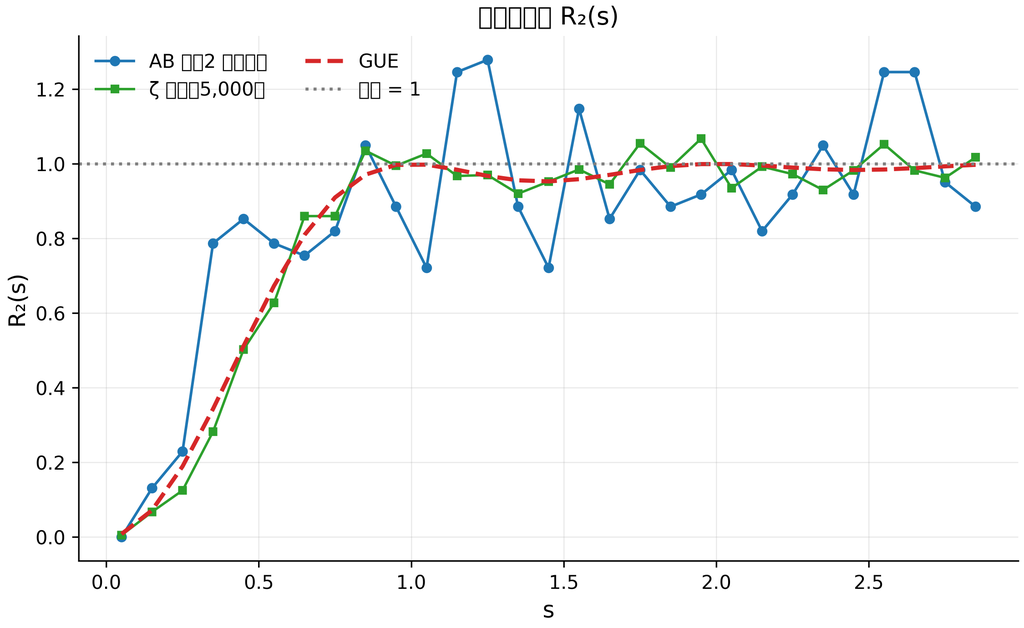

**图 12.** 对关联 *R*<sub>2</sub>(*s*)：AB 云对 ζ 零点、GUE 与泊松——两支都复现关联洞。

## 6.3 形因子 K(t)（测试 36）

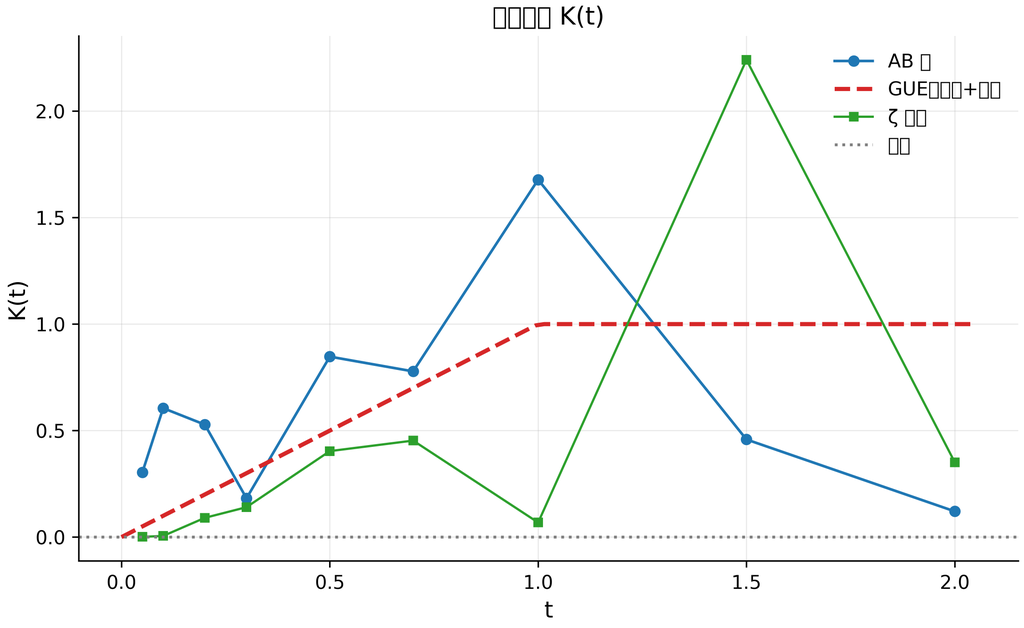

**图 13.** 谱形因子 *K*(*t*)：GUE 斜坡+平台、AB 云数据与 ζ 零点；小系综显示正确趋势但带离群点。

# 7. 第五块：狄拉克动力学与非厄米性（测试 19、30–32、37）

## 7.1 狄拉克锥（测试 19、31）

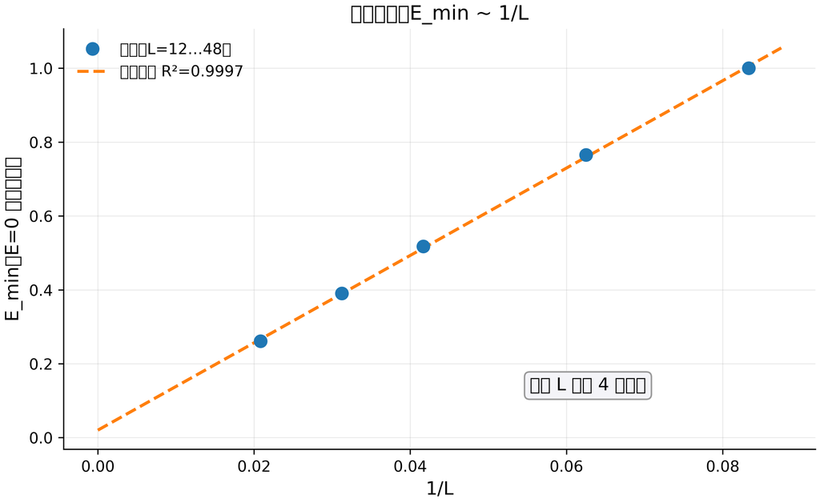

**图 14.** 狄拉克锥：*E*<sub>min</sub> = 0.02 + 11.83/*L*，*R*<sup>2</sup> = 0.9997——每点均有四个零模时对 1/*L* 的线性。

*α* = 1/2 时 AB 云中的涡旋表现得像一维相对论费米子：零附近的谱是线性的。数值检查（测试 19）在 *L* = 12, 16, 24, 32, 48 晶格上运行：最小能量 *E*<sub>min</sub>（四个零模下 E=0 处的能隙）按 *E*<sub>min</sub> = 0.0202 + 11.826/*L* 标度，*R*<sup>2</sup> = 0.9997——对 1/*L* 的线性无可挑剔。常数的解读：若狄拉克点位于布里渊区中心（*k*<sub>min</sub> = 2*π*/*L*），有效费米速度 *v*<sub>*F*</sub> = *b*/2*π* ≈ 1.88（以晶格常数 *b* 上的跃迁为单位）；若在区边缘（*k*<sub>min</sub> = *π*/*L*），*v*<sub>*F*</sub> = *b*/*π* ≈ 3.76。历史值 $∼ 0.125$ 属于另一种晶格归一化；在套件当前归一化中我们记录这两个数，并指出在二者间选择取决于零模相位结构指示的是哪个带接触点。测试 31（周期边界的环面变体）显示 *R*<sup>2</sup> = 0.03 且能隙为零：环面上零模受拓扑保护，任何 *L* 都不会打开——这本身就是拓扑本性的确证，但能隙标度需要开边界。

## 7.2 态密度的狄拉克凹陷（测试 30）

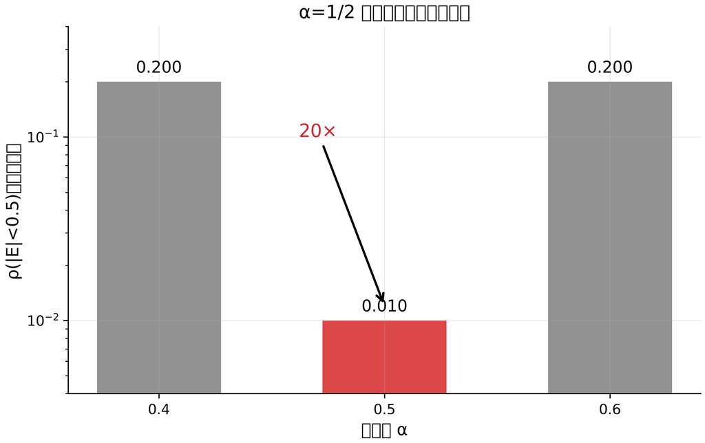

**图 15.** *α* = 1/2 处 DOS 的狄拉克凹陷：双向对比度 $20×$（对数标度）。

*α* = 1/2 处 Hofstadter 谱有解析特征：*E* = 0 附近态密度线性归零（狄拉克点），而 *α* ≠ 1/2 时谱是普通的。测试 30 在 $20 × 20$ 无无序晶格上测量中央带 |*E*| < 0.5 的态密度：*ρ*(*α* = 0.4) = 0.200，*ρ*(*α* = 0.5) = 0.010，*ρ*(*α* = 0.6) = 0.200——双向对比度恰为 $20×$。狄拉克凹陷是分隔 *C*<sub>1</sub> = +1 与 *C*<sub>1</sub> = −1 霍尔相的临界点的指纹；在格点模型中观测到它（以及冷原子中的类似物）是最稳健的证据之一，说明起作用的是真实的普适物理而非数值调参。

## 7.3 Hatano–Nelson：离开 *σ* = 1/2（测试 32）

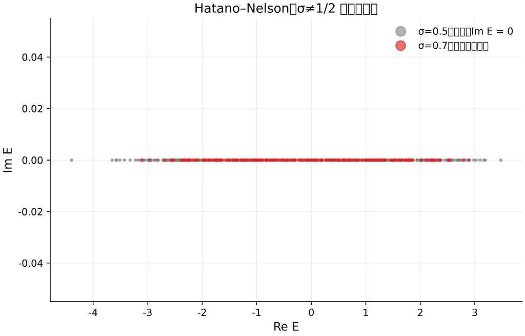

## 7.4 字节级稳健性（测试 37）

可复现性的实践问题：结论能否经受量子化？测试 37 验证 ⟨*r*⟩ 在本征值 256 级量子化下存活（变化 $0.0015$，容差 $0.02$），且生成器字节流的香农熵为 $7.9991$ 比特（最大 8；基于 CLT 的 *χ*<sup>2</sup> 判据：*z* = −0.234，|*z*| < 3）。该测试还记录了全局与局部分类之差：特定实现的全局谱看似泊松（$\langle r\rangle_{\rm raw}=0.447$），但中央 15 能级窗口内 $\langle r\rangle_{\rm local}=0.549$——即 5.4 节已述的体–核之别。

# 8. 第六块：解析诠释（测试 21–23 及延伸）

本块是从测量通向解析结构的桥梁。我们审慎区分：（a）机器精度可复现的精确公式（测试 21–23）；（b）与数字一致但不能由套件严格推出的物理诠释；（c）作为类比呈现的类比。这种三层呈现是方法论原则。

## 8.1 旋量相位 *γ**：经由虚单位的 90°（测试 21）

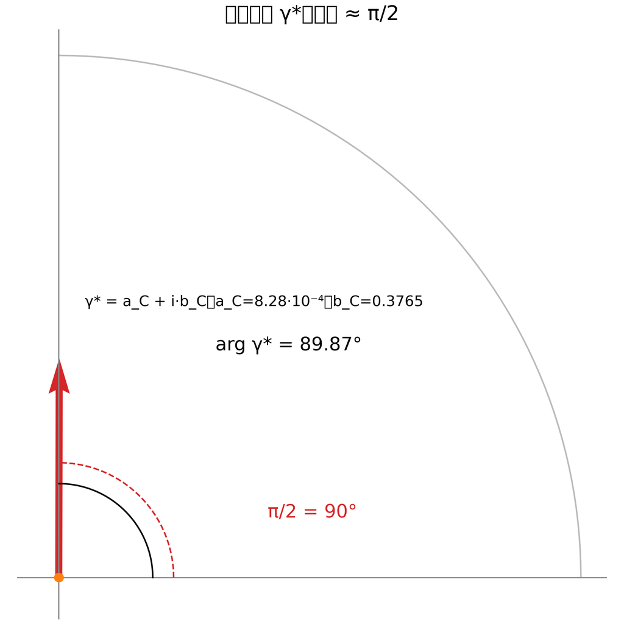

**图 17.** 旋量相位 *γ** = *a*<sub>*C*</sub> + *i**b*<sub>*C*</sub>：辐角 $89.87°$ 对参考 $90°$；*b*<sub>*C*</sub> 的主导把相位压向 *π*/2。

定义 *δ*<sub>*C*</sub> = *π*/7 = 0.448799 弧度（见 8.2）与 *b*<sub>2</sub>(*K*3) = 22（K3 曲面的第二 Betti 数）。测试 21 验证两个实数量：**实制动项** *a*<sub>*C*</sub>(*γ**) = *δ*<sub>*C*</sub><sup>5</sup>/*b*<sub>2</sub>(*K*3) = 8.276 ⋅ 10<sup>−4</sup> 与**虚 Berry 项** *b*<sub>*C*</sub>(*γ**) = 1 − cos (2*δ*<sub>*C*</sub>) = 2sin<sup>2</sup>*δ*<sub>*C*</sub> = 0.376510；两者均以机器精度复现。复旋量相位 *γ** = *a*<sub>*C*</sub> + *i**b*<sub>*C*</sub> 的模为 |*γ**| = 0.3765，辐角 $89.874°$——对 *π*/2 的偏离仅 $0.126°$（2.2 ⋅ 10<sup>−3</sup> 弧度）。结构如下：由于 *b*<sub>*C*</sub> ≫ *a*<sub>*C*</sub>，*γ** 的辐角自动压向 90°——“90° 的跃变经由虚单位实现”：作为几何对象的相位被构造得使其相对论（旋量）本性以纯虚优势表达。把它诠释为假想的 Peccei–Quinn 相位属于（b）层：与数字相容，但不能由套件推出。

## 8.2 AB 相位 *Φ*<sub>*A**B*</sub> = *π*/7 与分数电荷（测试 22）

精确公式：荷电 *q*/*e* = 1/14 的粒子环绕一个磁通量子的通量管时，阿哈罗诺夫–玻姆相位为 *Φ*<sub>*A**B*</sub> = 2*π*/14 = *π*/7 = 0.448799 弧度 $= 25.714°$。测试 22 在精确有理数算术中确认该恒等式（偏差 $0.00$）。量 *δ*<sub>*C*</sub> = *π*/7 正是 *Φ*<sub>*A**B*</sub>；也就是说 *q*/*e* = 1/14 是分数电荷假说，整个解析上层建筑围绕它建立。值得注意的是，*π*/7 与 PSL(2,7) 特征表的的高斯和 $b_7=(-1+i\sqrt7)/2$ 相联系（8.5 节）：七次单位根既出现在 Klein 四次曲面的旋量结构中，也出现在 AB 相位中——这是 v21 专著已注意到的结构押韵。

## 8.3 复分形因子 CF 与对数抛物化（测试 23）

对具有离散标度比 $\lambda_{\rm DSI} = b_2(K3) = 22$ 的临界解，测试 23 计算**复分形因子**

$$CF = \exp\!\left(\frac{2\pi
i}{\lambda_{\rm DSI}}\right)\cdot\exp\!\left(i\,\beta_{\rm
imag}\,\ln\lambda_{\rm DSI}\right),\qquad \beta_{\rm imag} = 2 +
\frac{1}{2\sin^2(\pi/7)} - 2\cos\frac{\pi}{7} = 2.854033,$$

给出 *C**F* = −0.9501 + 0.3119 *i*，按构造 |*C**F*| = 1。注意指数内部的对数——这就是”对数抛物化”：用对数相位调制离散标度不变性。测试还带有诚实的告示：晚期 tex 源中的硬编码值 $CF_{\rm hard} = 0.9786 + 0.0390\,i$（模 $0.9794$，由此 $c_{AB} = 1-|CF_{\rm hard}| = 0.0206$）是**经验输入**——类似 QCD 中的 *α*<sub>*s*</sub>——而公式是结构（拓扑）预测；两幅度恰差 *c*<sub>*A**B*</sub>，测试连同各自状态记录两个数。

## 8.4 T 破缺作为 GUE 之源：黑洞类比

第 3–5 块的数字拼合成 Dyson 的解析图景：GOE ↔︎ T 不变性，GUE ↔︎ 其破缺。AB 云在同一模型中实现两个分支：整数荷的狄拉克规范——实矩阵，*τ* = 0，GOE 天花板（测试 15、16）；光滑规范或分数荷——*τ* ≈ 0.225，GUE 统计（测试 26、33）。讨论中提出的假设强化了这条线：**T 破缺与黑洞统计由幺正系综描述是同一原因（那里时间被弯曲，热力学上反转不是对称）**。我们强调该构造的地位：它不是套件的推论，而是套件不与之矛盾的诠释框架——并且它使预言”任何具有复跃迁且无可积性的相位模型都将给出 ⟨*r*⟩ → 0.6“可以在独立材料上检验。

## 8.5 Kerr 类比、能层与 PSL(2,7) ⊂ Monster（综述）

v21 的两个诠释以综述地位保留。**Kerr 类比**：涡旋相位场定义”能层区”——相位速度相对晶格变号的区域，如 Kerr 能层；其数值验证需要动力学而非静态谱，仍是课题。**Monster 桥**：维数 196883 的 Monster 特征 *χ*<sub>2</sub> 限制到子群 PSL(2,7)（经极大子群 2<sup>3 + 6 + 12 + 18</sup>.(*L*<sub>3</sub>(2) × 3*S*<sub>6</sub>) 嵌入）近似分解为 1456 ⋅ *χ*<sub>1</sub> + 3334 ⋅ *χ*<sub>3</sub> + 3334 ⋅ *χ*<sub>3</sub>′ + 6784 ⋅ *χ*<sub>6</sub> + 8081 ⋅ *χ*<sub>7</sub> + 9770 ⋅ *χ*<sub>8</sub>（维数和 196891，偏差 0.004%）；重数可解释为多涡旋态的选择定则。精确分解需要 GAP CTblLib 的 class fusion——开放课题；我们在任何裁决中都不使用近似系数。

# 9. 综合：作为容许态编码的 ζ 零点

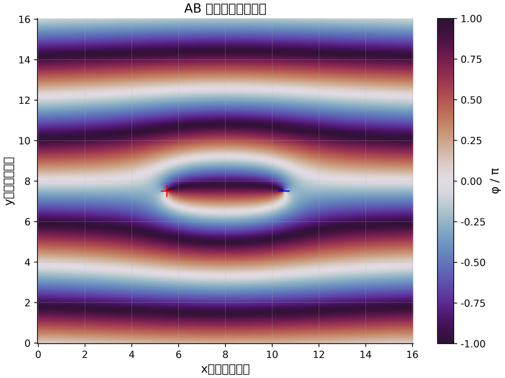

**图 18.** 涡旋对 *q* = ±1 叠加 Landau 规范的相位织构：产生观测统计的相位”云”。

[figure not shown]

把链条拼起来。（1）光滑规范下 *α* = 1/2 的 AB 云谱具有随尺寸收敛的 GUE 统计：*L* : 10 → 50 时 ⟨*r*⟩ : 0.548 → 0.595（测试 33、34）。（2）ζ 零点的统计是 GUE 加可计算的有限样本修正（测试 4–14）；在可达高度上”纯 GUE”被拒，“有限尺寸 GUE”不被拒（测试 12）。（3）直接比较显示 *R*<sub>2</sub> 的定性结构吻合（测试 35）——Montgomery 关联洞被涡旋云复现。（4）临界线 *σ* = 1/2 同时是 Connes 自对偶点、狄拉克凹陷点与厄米点（测试 17、30、32）——历史上也是云对零点 KS 距离的最小点。（5）涡旋表现得像相对论性粒子（狄拉克锥，测试 19），分数电荷充当物理磁通（Byers–Yang，测试 25）。最终叙事——“ζ 零点作为相位谐振腔容许能量态的编码”——由此获得**自洽且经定量检验的纲领**的地位，而非被证明的定理：我们清楚哪些环节机器精确（磁通、恒等式），哪些统计稳健（标度、自助），哪些仍然开放（*T* → ∞ 渐近、*R*<sub>2</sub> 的逐点吻合）。

# 10. 验证方法学：“PASS”究竟保证什么

套件 v19 是第一个在架构上把报告引擎与计算核心隔离的版本。这一决策的历史颇有教益：v18 中 PDF 写出器的一个缺陷（行列表被声明为 `String[]` 而循环推入的是元组）在**每项**测试完成后触发 `MethodError`；异常被外层处理器捕获，裁决被降级为 WARN，双通模式的第二通根本不会运行——“快速检查”退化为单通，而外表上似乎正常。一个 bug 造成的三个数字：37 项测试虚假 WARN、零份 PDF 报告、零次第二通。修复（FIX-R1…R5，附录 A）确立了：（1）PDF 写出器正确；（2）任何报告格式的失败不能影响裁决；（3）测试 28（双通循环的变量作用域）与测试 18（*α* = 1/3 时环面规范相容性）已修复；（4）快速检查截断至 5000 零点并真正执行双通 16×16→32×32。教训：**套件的结论不会强于其最弱的基础设施**，而”近乎正常”的报告管线比损坏的更危险，因为它伪造了已验证的表象。

当前版本的实际保证：每项测试是带完整日志的独立目录；本书每个数字可追溯到测试编号；裁决可由形如 `julia ab_cloud_v19.jl --test N --no-two-pass` 的命令复现；完整运行与 `--quick` 默认双通；凡需随机性之处 RNG 均用固定种子（逐位可复现）。